# R for Beginners: Variables and Functions

C. Tobin Magle

Jan 11, 2017

This material was adapted from the Software Carpentry [Inflammation](http://swcarpentry.github.io/r-novice-inflammation/01-starting-with-data.html) and Gapminder lessons. This document and associated script can be found at https://github.com/maglet/r-for-beginners

# Functions

Functions are discete units of R code that allow you to perform specific tasks. You can find functions:

- **In the R base package**: no extra installation required.
- **In external packages**: because R is open source, many people create their own functions for specific purposes and make them available in the CRAN repository.
- **Make your own!**: you can write your own functions.

We’ll be using functions from the base package in this tutorial.

Now we’ll go over some really useful functions to use in R.

### Loading files

You can use the assignment operator to load tabular data into R.

Let’s use a data table called **gapminder.csv** that contains population, gross domestic product, and life expectancy information for countries worldwide

#### Downloading files

You can download the file at this address: here

But why not use R to do the downloading for you? That’s what the **download.file** function is for.

Here’s the code to download a file in R.

```r
download.file("https://raw.githubusercontent.com/swcarpentry/r-novice-gapminder/gh-pages/_episodes_rmd/data/gapminder-FiveYearData.csv", #the URL that contains the file
              destfile = "gapminder.csv")  #What to call the file
```

See what I mean about ‘=’ being used for something different in R? It’s used to give the function’s **arguments** values. Arguments are information that the function needs to run. In this case, we need to know where the file is online and where you want to store it locally.

- The **url** argument specifies where the file is on the web
- The **destfile** argument specifies where you want the downloaded data to be stored. If you don’t include a file path, the function saves the file in the working directory.
- Make sure both the url and the destination file are in quotes.

If you’re not sure what arguments a function can take, type “help(FunctionName)”. This command will open the help file for the function in the lower right of the R Studio console.

For example, this is how you’d pull up the help file for **download.file**

```r
help(download.file) # get R documentation for download.file function
```

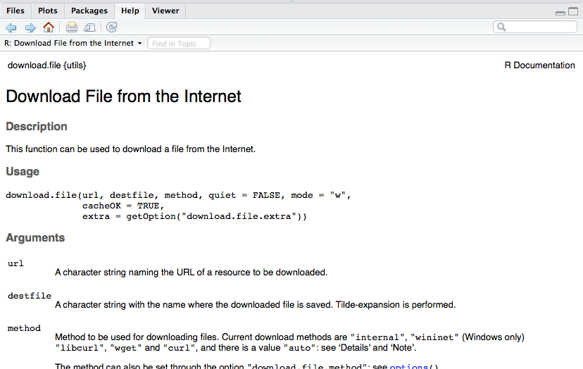

It takes a while to learn how to effectively read the R help files, but don’t worry. We will explain all of the functions and arguments you need in this tutorial. You shouldn’t have to rely much on the help files.

#### Loading data into R

Now that you’ve downloaded the data you, you can load it into R. We’re going to use the assignment operator and the **read.csv** function.

Below is the syntax to read the **gapminder.csv** file into R.

```r
gapminder <- read.csv("gapminder.csv") #reads data from the csv file
```

Now your global environment looks something like this:

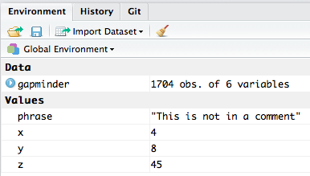

There’s a new dataset called **gapminder**. Descriptive variable names are good.

### Inspecting your data

What you can do with the data set in r depends on the content and type of data in **gapminder**.

To find out the format that R is storing the data in, you can use the function **class**. Every variable in R has a class, including the variables **x** from earlier. Let’s see what class these two items are.

```r
x<-4
class(x)
```

```
## [1] "numeric"
```

**x** is a numeric variable.

```r
phrase<-"This is not in a comment"
class(phrase)
```

```
## [1] "character"
```

**phrase** is character, as expected.

```r
gapminder<-read.csv("gapminder.csv")
class(gapminder)
```

```
## [1] "data.frame"
```

gapminder is a **data frame**. This is a special R format that makes dealing with tabular data easier.

To see how the data are formatted in a data frame, you can use the **head** command. It takes one argument (the data frame).

```r
head(gapminder) #displays the first 6 elements of all columns
```

```
##       country year      pop continent lifeExp gdpPercap
## 1 Afghanistan 1952  8425333      Asia  28.801  779.4453
## 2 Afghanistan 1957  9240934      Asia  30.332  820.8530
## 3 Afghanistan 1962 10267083      Asia  31.997  853.1007
## 4 Afghanistan 1967 11537966      Asia  34.020  836.1971
## 5 Afghanistan 1972 13079460      Asia  36.088  739.9811
## 6 Afghanistan 1977 14880372      Asia  38.438  786.1134
```

By default, **head** will display the first 6 values of each column in the data frame.

If you want to see the entire data frame in a new tab, click on the name of the variable in the **Environment** window. A spreadsheet will open as a new tab in the editor (upper left).

[figure not shown]

To find out what data type is contained in each column, use the **str** command (which stands for structure) to get more information.

```r
str(gapminder)
```

```
## 'data.frame':    1704 obs. of  6 variables:
##  $ country  : Factor w/ 142 levels "Afghanistan",..: 1 1 1 1 1 1 1 1 1 1 ...
##  $ year     : int  1952 1957 1962 1967 1972 1977 1982 1987 1992 1997 ...
##  $ pop      : num  8425333 9240934 10267083 11537966 13079460 ...
##  $ continent: Factor w/ 5 levels "Africa","Americas",..: 3 3 3 3 3 3 3 3 3 3 ...
##  $ lifeExp  : num  28.8 30.3 32 34 36.1 ...
##  $ gdpPercap: num  779 821 853 836 740 ...
```

In this dataset, the year, pop, lifeExp and gdpPercap contain numbers (num or int).

But what does it mean to say that **country** and **continent** are factors? **Factors** are categorical data that describe the observation.

- **country** is a factor with 142 levels, the number of countries in this dataset.
- **continent** is a factor with 5 levels, the 5 continents represented in this dataset

You can use factors to split the data subgroups. We’ll come back to this point in pt 4 of this lesson.

Finally, to get the min, max, median, mean, and quartiles for the numerica data, and the counts for the factor variables, you can use the **summary** command.

```r
summary(gapminder)
```

```
##         country          year           pop               continent
##  Afghanistan:  12   Min.   :1952   Min.   :6.001e+04   Africa  :624
##  Albania    :  12   1st Qu.:1966   1st Qu.:2.794e+06   Americas:300
##  Algeria    :  12   Median :1980   Median :7.024e+06   Asia    :396
##  Angola     :  12   Mean   :1980   Mean   :2.960e+07   Europe  :360
##  Argentina  :  12   3rd Qu.:1993   3rd Qu.:1.959e+07   Oceania : 24
##  Australia  :  12   Max.   :2007   Max.   :1.319e+09
##  (Other)    :1632
##     lifeExp        gdpPercap
##  Min.   :23.60   Min.   :   241.2
##  1st Qu.:48.20   1st Qu.:  1202.1
##  Median :60.71   Median :  3531.8
##  Mean   :59.47   Mean   :  7215.3
##  3rd Qu.:70.85   3rd Qu.:  9325.5
##  Max.   :82.60   Max.   :113523.1
##
```

### Take home points:

- You can find functions in the base R installation, packages, or create your own
- Functions can help you download files (download.file) and import data (read.csv)
- Base R has usefil functions for examining values and data (class, str, head, summary)

### Challenge Questions

1. How would you find the help file for par: a function that alters graphics parameters?
2. What is the second argument of the t.test function?
3. What happens if you don’t use the destfile argument in the download.file function?